# Jan 28, 2025

Experiment 01 - Week 04  
Cooling Mechanisms and Modelling

Name: Camus Wang  
Partner: Fei Chi Kristy Yuen

## Background theoretical knowledge (before lab)

#### Three primary mechanisms of heat transfer

- **Conduction**
  - Conduction describes the transfer of heat through a material due to the temperature gradient with a proportionality constant, which is called the **thermal conductivity of the material**.
  - $$\frac{dQ}{dt} = -kA\frac{dT}{dx}$$ k is the thermal conductivity of the material, A is the cross-sectional area, and $\frac{dQ}{dt}$ represents the rate of heat transfer.
  - Note: The numerical values of the conductivity vary over many orders of magnitude from one material to another.
- **Radiation**
  - Radiation describes the process by which heat energy is emitted from a surface in the form of electromagnetic wave, using Stefan-Boltzmann law:
  - $$\frac{dQ}{dt} = -\sigma e A (T^4 - T_0^4)$$ T is the temperature of the object in Kelvin (so $T^4-T_0^4$ describes the temperature difference between the object and its environment), e is the emissivity of the material and it is the **Stefan-Boltzmann constant**, A is the surface area of the sample.
- **Convection**
  - Convection describes heat transfer through fluid motion, using Newton's law of cooling provides a simple model:
  - $$\frac{dQ}{dt} = -hA(T - T_0)$$ $T-T_0$ is the temperature difference, A is the surface area, h is the **convection coefficient**
  - Note: h depends on fluid and temperature differences, **for a cylindrical objects, an empirical formula is used**: $$h = 1.32 \frac{J}{m^{7/4} \, s \, K^{5/4}} \left( \frac{T - T_0}{D} \right)^{1/4}$$ D is the diameter.
- **Cooling Rate and Heat Capacity**
  - $$\frac{dQ}{dt} = MC\frac{dT}{dt} = \rho VC\frac{dT}{dt}$$
  - M= mass
  - $\rho$= density
  - V= volume
  - C= capacity
  - Combining conduction, converction, and radiation, the total cooling rate can be modeled.

## Analysis of the heat transfer of the aluminum rods

Last time we learned that there are three ways heat can be transferred: Conduction, Radiation, and Convection

- Here are three aluminum rods with different surface properties (rough, polished, and lacquered), which are supported by wooden rods.
- Dare to predict the heat transfer methods here. There is a temperature difference between the heated aluminum rod and the wooden rod, and there is a **conduction** according to the theoretical thermal conductivity. The heated aluminum rod will also emit heat by **radiation**. The emissivity of the three different surfaces will be different. The temperature of the air around the heated aluminum rod will also be different from the room temperature, and there will be **convection** heat transfer here.
- In general, Cooling rate $(\frac{dQ}{dt}) = MC\frac{dT}{dt}$ = Conduction + Radiation + Convection

-> $$\rho VC\frac{dT}{dt} = -kA\frac{dT}{dx}-\sigma e A (T^4 - T_0^4)-hA(T - T_0)$$

## Measurement

1. In this experiment, we need to temporarily “block” the effect of conduction. When we insert the thermometer into the rod, we need to keep the position unchanged to avoid the change of conduction caused by different positions in the rod. Keeping the heat transfer of the conduction part constant, the remaining part of the equation (cooling rate) can be used to form an ODE for us to fit and find the emissivity of different surfaces.
2. For each aluminum rod, find and record:
   - the room temperature
   - the dimater of aluminum rod
   - the length of aluminum rod
   - the mass of aluminum rod
   - the capacity of aluminum rod
   - the Stefan-Boltzmann constant $\sigma$
   - h depends on fluid and temperature differences, for a cylindrical objects, an empirical formula is used: $$h = 1.32 \frac{J}{m^{7/4} \, s \, K^{5/4}} \left( \frac{T - T_0}{D} \right)^{1/4}$$ D is the diameter
3. After finding the above constants, the following independent operations are performed on each rod: heating in hot water, then cooling in air. Record the change in temperature over time, end when $T-T_0 < 5{\textdegree}C$, remember to record as many data points as possible between the initial and final temperatures after heating, as well as the corresponding times.
4. Use "solve_ivp" to model this system to match the collected data: $$\rho VC\frac{dT}{dt} = -kA\frac{dT}{dx}-\sigma e A (T^4 - T_0^4)-hA(T - T_0)$$
5. Our aim is to see if the formula can fit the data points well (judged by the chi-squared value), and thus obtain the emissivity of rods with different surfaces, compare the emissivity of the three different surfaces, compare the gaps in our predictions, and analyze the potential causes.

## Uncertainty estimate

1. The uncertainty of dimater come from vernier caliper, the uncertainty of length come from ruler, the uncertainty of mass come from scale, All above uncertain values are mainly from instrument uncertainty, so we use Gaussian uncertainty and 68% confidence interval (minimum unit / 2)
2. The uncertainty of temperature come from thermometer, it is mainly from instrument uncertainty and visual inspection, we determine to use Gaussian uncertainty and 68% confidence interval (minimum unit / 2)

## Experiment Timeline

#### Week-02 Task

Use the diameter and length of the rods measured in the previous week, **re-measure** accurately the data points of the temperature change over time after heating the rods, and remember that three different surfaces of the rods are heated separately, **Plot** three sketches of Temperature change over Time, then try to **understand** "solve_ivp" from Phys210-Reading-11, and so that can fit the data next week.

#### Week-03 Task

1. Firstly, determine the constant such as density, cross-sectional area, Stefan-Boltzmann constant... **Find reliable data you can trust.**
2. Then try to use solve_ivp to **correctly express** the solution to the heat transfer equation.
3. Finally, try to use this theoretical model to **fit** the three sets of data points, and then **troubleshooting**.

#### Week-04 Task

1. Continue to fit data sets (use curve_fit to fit two parameters: emissivity $e$ and conduction term $\beta$), get the final results (chi-squared and residuals plot and cooling rate) and then comment the fit.
2. Try to write some summary that this experiment we learned

```python
import numpy as np
import array
import pandas as pd
import matplotlib.pyplot as plt
import data_entry2
from scipy.integrate import solve_ivp
from scipy.optimize import curve_fit
```

## Data: Polished Aluminum Rod

```python
de = data_entry2.sheet("polished-rod.csv")
```

```
Sheet name: polished-rod.csv
```

```python
# Measured Constant
T_0 = 21.7 # C

# Polished rod
length1 = 30.37 # cm
ulenght1 = 0.1/2 # cm

dimater1 = 2.595 # cm
udimater1 = 0.005/2 # cm

mass1 = 428 # g
umass1 = 1/2 # g

density1 = mass1 / ((dimater1/2)**2*np.pi*length1)
print(f"The density of Polished aluminum rod is: {density1:.2f} g/cm^3")
```

```
The density of Polished aluminum rod is: 2.66 g/cm^3
```

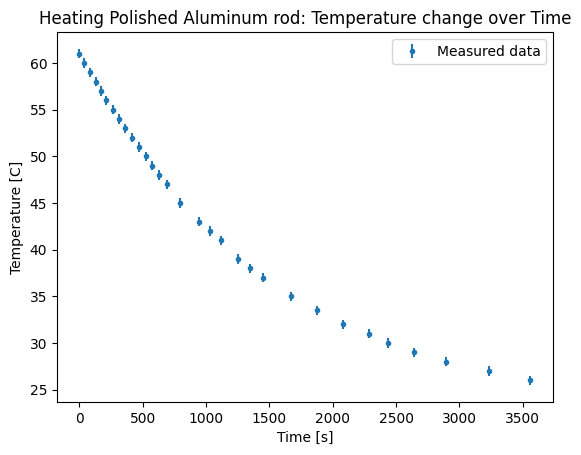

```python
# Plot
plt.errorbar(TimePVec,TemPVec, yerr=uTemPVec, marker=".", linestyle="",label="Measured data")
plt.xlabel("Time [s]")
plt.ylabel("Temperature [C]")
plt.title("Heating Polished Aluminum rod: Temperature change over Time")
plt.legend()
plt.show()
```

## Data: Lacquered Aluminum Rod

```python
de = data_entry2.sheet("lacquered-rod.csv")
```

```
Sheet name: lacquered-rod.csv
```

```python
# lacuered rod
length2 = 30.49 # cm
ulength2 = 0.1/2 # cm

dimater2 = 2.510 # cm
udimater2 = 0.005/2 # cm

mass2 = 403 # g
umass2 = 1/2 # g

density2 = mass2 / ((dimater2/2)**2*np.pi*length2)

print(f"The density of Lacuered aluminum rod is: {density2:.2f} g/cm^3")
```

```
The density of Lacuered aluminum rod is: 2.67 g/cm^3
```

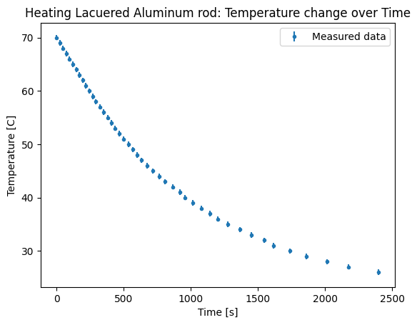

```python
# Plot
plt.errorbar(TimeLVec,TemLVec, yerr=uTemLVec, marker=".", linestyle="",label="Measured data")
plt.xlabel("Time [s]")
plt.ylabel("Temperature [C]")
plt.title("Heating Lacuered Aluminum rod: Temperature change over Time")
plt.legend()
plt.show()
```

## Data: Rough Aluminum Rod

```python
de = data_entry2.sheet("rough-rod.csv")
```

```
Sheet name: rough-rod.csv
```

```python
# Rough rod
length3 = 30.35 # cm
ulength3 = 0.1/2 # cm

dimater3 = 2.530 # cm
udimater3 = 0.005/2 #cm

mass3 = 406 # g
umass3 = 1/2 # g

density3 = mass3 / ((dimater3/2)**2*np.pi*length3)

print(f"The density of Rough aluminum rod is: {density3:.2f} g/cm^3")
```

```
The density of Rough aluminum rod is: 2.66 g/cm^3
```

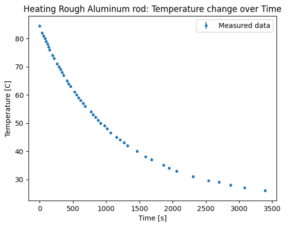

```python
# Plot
plt.errorbar(TimeRVec,TemRVec, yerr=uTemRVec, marker=".", linestyle="",label="Measured data")
plt.xlabel("Time [s]")
plt.ylabel("Temperature [C]")
plt.title("Heating Rough Aluminum rod: Temperature change over Time")
plt.legend()
plt.show()
```

**End of Week-2**

## Fitting

#### Simplify the theoretical model

$$\rho VC\frac{dT}{dt} = -kA\frac{dT}{dx}-\sigma e A (T^4 - T_0^4)-hA(T - T_0)$$ -> $$\frac{dT}{dt} = -\frac{1}{\rho VC}(kA\frac{dT}{dx}+\sigma e A (T^4 - T_0^4)+hA(T - T_0))$$ -> (Assume the aluminum rod as a “uniform temperature distribution” and do not consider the temperature gradient inside the rod, which means $\frac{dT}{dx}=const$) $$\frac{dT(t)}{dt} = -\frac{1}{\rho VC}(\beta+\sigma e A (T(t)^4 - T_0^4)+hA(T(t) - T_0))$$ where $\beta$ is a constant

Code-block context: Define some function that we can use later

```python
# Define the ODE equation of theoretical model
def heat_ode(t, T, rho, V, C, beta, sigma, e, A, T0, D):
    h = 1.32*(abs((T-T0))/D)**(1/4)
    rad_part = sigma*e*A*(T**4-T0**4)
    conv_part = h*A*(T-T0)
    cond_part = beta
    dTdt = -1/(rho*V*C)*(cond_part+rad_part+conv_part)
    return dTdt

def heat_ode_packed(t,T):
    return heat_ode(t, T, rho, V, C, beta, sigma, e, A, T0, D)
```

```python
def chi_square(exp_data, model_data, exp_uncertainty):
    residuals = exp_data - model_data
    chi2 = np.sum( (residuals / exp_uncertainty)**2 )
    return chi2
```

#### Find reliable Stefan-Boltzmann Constant

$\sigma\approx 5.67\times10^{-5} gs^{-3}K^{-4}$ from WIKIPEDIA

#### Find reliable Capacity

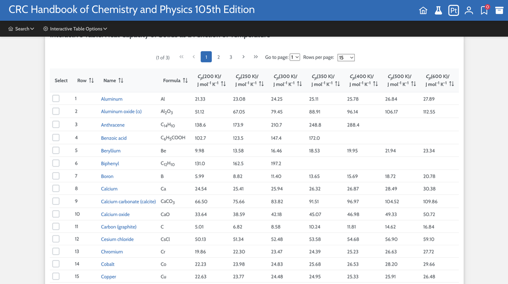

https://hbcp-chemnetbase-com.eu1.proxy.openathens.net/contents/InteractiveTable.xhtml?dswid=3194

I found a reliable source of data through the UBC Library, Since our measurement temperature range is from ~360-295, so we choose the average of $C_p(300K)$ and $C_p(350K)$ as our Capacity, which is $(25.11+24.25)/2=24.68 Jmol^{-1}K^{-1}=\frac{24.68}{26.98} Jg^{-1}K^{-1}\approx0.915Jg^{-1}K^{-1}$

#### For Polished Aluminum rod

Code-block context: Hopefully the code will show that the theoretical formula ($\frac{dT(t)}{dt} = -\frac{1}{\rho VC}(\beta+\sigma e A (T(t)^4 - T_0^4)+hA(T(t) - T_0))$ ) describes the measured data (Polished) well and find estimated emissivity of Polished Aluminum rod from fit.

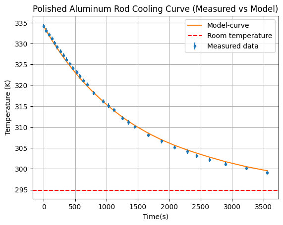

```python
# Set constant of Polished Aluminum Rod
T0 = 21.7 + 273.15 # K
rho = density1*(100)**3 # g/m^3
V = ((dimater1/2)*0.01)**2*np.pi*(length1*0.01) # m^3
C = 0.915 # J/(g*K)
beta = 0 # Guess
sigma = 5.67e-5 # g*s^(-3)*K^(-4)
e = 0.07 # Guess
A = ((dimater1/2)*0.01)**2*np.pi # m^2
D = dimater1*0.01 # m

# Use solve_ivp
T_initial = 61 + 273.15 # K
t_start, t_stop = 0, 3560 # s ; time interval
# t_eval = np.linspace(t_start, t_stop, 201) # time partitions
t_eval = TimePVec
sol = solve_ivp(heat_ode_packed, (t_start, t_stop), [T_initial], t_eval=t_eval, method="RK45")
timesP = sol.t
T_resultsP = sol.y[0]

# Plot
plt.errorbar(TimePVec,TemPVec + 273.15, yerr=uTemPVec, marker=".", linestyle="",label="Measured data")
plt.plot(timesP, T_resultsP, label = "Model-curve")
plt.axhline(T0, color="r", linestyle="--", label="Room temperature")
plt.xlabel("Time(s)")
plt.ylabel("Temperature (K)")
plt.title("Polished Aluminum Rod Cooling Curve (Measured vs Model)")
plt.legend()
plt.grid()
plt.show()
```

Comment: It shows theoretical formula with some setting of parameters can describes the measured data (Polished) well, and the estimated $e_{Polished}=0.07$, but then we need to calculate chi-squered to accurately determine the relationship between the model and the data.

#### For Lacquered Aluminum rod

Code-block context: Hopefully the code will show that the theoretical formula ($\frac{dT(t)}{dt} = -\frac{1}{\rho VC}(\beta+\sigma e A (T(t)^4 - T_0^4)+hA(T(t) - T_0))$ ) describes the measured data (Lacquered) well and find estimated emissivity of Lacquered Aluminum rod from fit.

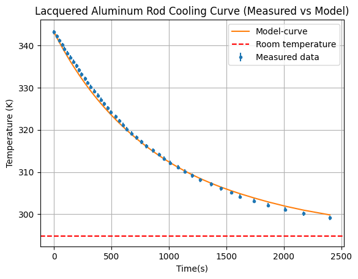

```python
# Set constant of Lacquered Aluminum Rod
T0 = 21.7 + 273.15 # K
rho = density2*(100)**3 # g/m^3
V = ((dimater2/2)*0.01)**2*np.pi*(length2*0.01) # m^3
C = 0.915 # J/(g*K)
beta = 0
sigma = 5.67e-5 # g*s^(-3)*K^(-4)
e = 0.11 # Guess
A = ((dimater2/2)*0.01)**2*np.pi # m^2
D = dimater2*0.01 # m

# Use solve_ivp
T_initial = 70 + 273.15 # K
t_start, t_stop = 0, 2400 # s ; time interval
t_eval = TimeLVec # time partitions
sol = solve_ivp(heat_ode_packed, (t_start, t_stop), [T_initial], t_eval=t_eval, method="RK45")
timesL = sol.t
T_resultsL = sol.y[0]

# Plot
plt.errorbar(TimeLVec,TemLVec + 273.15, yerr=uTemLVec, marker=".", linestyle="",label="Measured data")
plt.plot(timesL, T_resultsL, label = "Model-curve")
plt.axhline(T0, color="r", linestyle="--", label="Room temperature")
plt.xlabel("Time(s)")
plt.ylabel("Temperature (K)")
plt.title("Lacquered Aluminum Rod Cooling Curve (Measured vs Model)")
plt.legend()
plt.grid()
plt.show()
```

Comment: It shows theoretical formula with some setting of parameters can describes the measured data (Lacquered) well, and the estimated $e_{Lacquered}=0.11$, but then we need to calculate chi-squered to accurately determine the relationship between the model and the data.

#### For Rough Aluminum rod

Code-block context: Hopefully the code will show that the theoretical formula ($\frac{dT(t)}{dt} = -\frac{1}{\rho VC}(\beta+\sigma e A (T(t)^4 - T_0^4)+hA(T(t) - T_0))$ ) describes the measured data (Rough) well and find estimated emissivity of Rough Aluminum rod from fit.

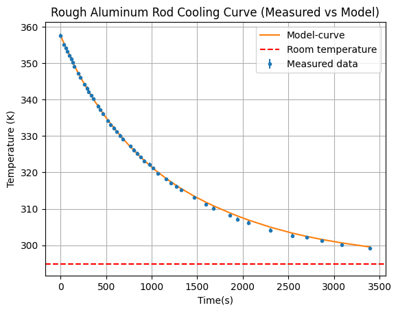

```python
# Set constant of Rough Aluminum Rod
T0 = 21.7 + 273.15 # K
rho = density3*(100)**3 # g/m^3
V = ((dimater3/2)*0.01)**2*np.pi*(length3*0.01) # m^3
C = 0.915 # J/(g*K)
beta = 0
sigma = 5.67e-5 # g*s^(-3)*K^(-4)
e = 0.087 # Guess
A = ((dimater3/2)*0.01)**2*np.pi # m^2
D = dimater3*0.01 # m

# Use solve_ivp
T_initial = 84.5 + 273.15 # K
t_start, t_stop = 0, 3394 # s ; time interval
t_eval = TimeRVec # time partitions
sol = solve_ivp(heat_ode_packed, (t_start, t_stop), [T_initial], t_eval=t_eval, method="RK45")
timesR = sol.t
T_resultsR = sol.y[0]

# Plot
plt.errorbar(TimeRVec,TemRVec + 273.15, yerr=uTemRVec, marker=".", linestyle="",label="Measured data")
plt.plot(timesR, T_resultsR, label = "Model-curve")
plt.axhline(T0, color="r", linestyle="--", label="Room temperature")
plt.xlabel("Time(s)")
plt.ylabel("Temperature (K)")
plt.title("Rough Aluminum Rod Cooling Curve (Measured vs Model)")
plt.legend()
plt.grid()
plt.show()
```

Comment: It shows theoretical formula with some setting of parameters can describes the measured data (Rough) well, and the estimated $e_{Rough}=0.087$, but then we need to calculate chi-squered to accurately determine the relationship between the model and the data

**End of week-3**

## Continue fitting (week-4)

Code-block context: Since we get the theoretical heat transfer model by solve_ivp, we want to get the best fitted parameters ($e$ and $\beta$) without hand fit, so here we introduce a method "curve_fit", which can fit a data sets with a function, by this way, we will deeply analysis what means about $\beta=kA\frac{dT}{dx}$, and analysis the degree of model and data fit.

#### For Polished Aluminum rod

```python
def cooling_model_Polished(t, e, beta):
    T0 = 21.7 + 273.15 # K
    rho = density1*(100)**3 # g/m^3
    V = ((dimater1/2)*0.01)**2*np.pi*(length1*0.01) # m^3
    C = 0.915 # J/(g*K)
    sigma = 5.67e-5 # g*s^(-3)*K^(-4)
    A = ((dimater1/2)*0.01)**2*np.pi # m^2
    D = dimater1*0.01 # m

    def heat_ode_fitting(t,T):
        h = 1.32*(abs((T-T0))/D)**(1/4)
        rad_part = sigma*e*A*(T**4-T0**4)
        conv_part = h*A*(T-T0)
        cond_part = beta
        return -1/(rho*V*C)*(cond_part+rad_part+conv_part)
    sol = solve_ivp(heat_ode_fitting, (0, max(t)), [61+273.15], t_eval=t)
    return sol.y[0]
```

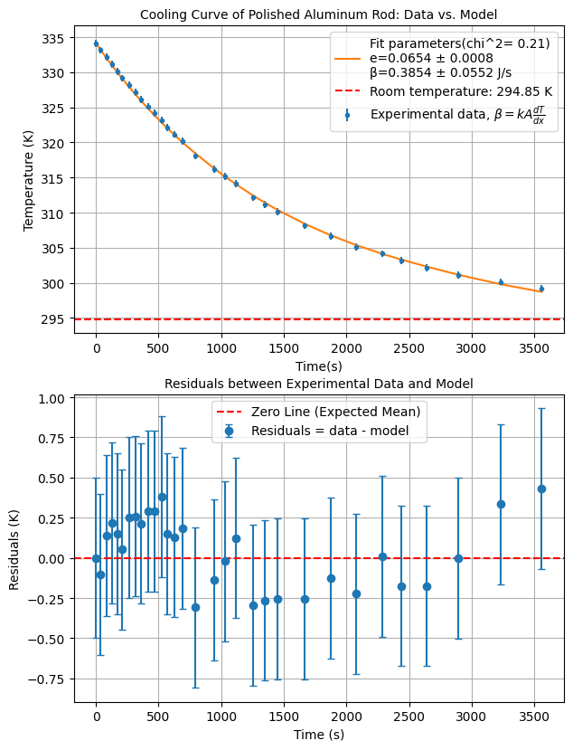

```python
font_size = 10

t_data = TimePVec
T_data = TemPVec + 273.15

initial_guess = [0.07,0]

popt, pcov = curve_fit(cooling_model_Polished, t_data, T_data, p0=initial_guess)

e_fit, beta_fit = popt
e_err, beta_err = np.sqrt(np.diag(pcov))

T_fit = cooling_model_Polished(t_data, e_fit, beta_fit)

# compute chi-square
T_err = uTemPVec
residuals = T_data - T_fit
chi2 = np.sum((residuals / T_err)**2)
dof = len(T_data) - len(popt)
chi2_squared = chi2 / dof

# Plot
fig = plt.figure(figsize=(7,15))
ax1 = fig.add_subplot(311)
ax2 = fig.add_subplot(312)

# the cooling curve plot
ax1.errorbar(t_data,T_data, yerr=T_err, marker=".", linestyle="",label=r"Experimental data, $\beta=kA\frac{dT}{dx}$")
ax1.plot(t_data, T_fit, label = f"Fit parameters(chi^2= {chi2_squared:.2f})\ne={e_fit:.4f} ± {e_err:.4f}\nβ={beta_fit:.4f} ± {beta_err:.4f} J/s")
ax1.axhline(T0, color="r", linestyle="--", label="Room temperature: 294.85 K")
ax1.set_xlabel("Time(s)", fontsize=font_size)
ax1.set_ylabel("Temperature (K)", fontsize=font_size)
ax1.set_title("Cooling Curve of Polished Aluminum Rod: Data vs. Model", fontsize=font_size)
ax1.grid()
ax1.legend()

# the resiudals plot
ax2.errorbar(TimePVec, residuals, yerr=T_err, fmt="o", capsize=3, label="Residuals = data - model")
ax2.axhline(0, color="r", linestyle="--", label="Zero Line (Expected Mean)")
ax2.set_xlabel("Time (s)", fontsize=font_size)
ax2.set_ylabel("Residuals (K)", fontsize=font_size)
ax2.set_title("Residuals between Experimental Data and Model", fontsize=font_size)
ax2.grid()
ax2.legend()

plt.show()
```

Comment: **Overall**, i find if we cheat conduction term as constant, the model can't fit the expermental datas well, since the residuals plot shows a clear trend: the residuals are positive for data points around 0-750 seconds, and negative for data points around 750-3000 seconds. But, we can consider the fitted emissivity and conduction term to be of reference values.

**Consider whether we can ignore the contribution of the conduction part to cooling?**

$$\frac{dT(t)}{dt} = -\frac{1}{\rho VC}(\beta+\sigma e A (T(t)^4 - T_0^4)+hA(T(t) - T_0))$$, now we define $$P=\frac{\beta}{\beta+\sigma e A (T(t)^4 - T_0^4)+hA(T(t) - T_0)}$$ and $$\beta=kA\frac{\Delta T}{L}$$ where L is the length of rod and $\Delta T$ is the temperature different between the top of rod and the bottom of rod.

From this, we observe that P depends on time in our model, since we assume the temperature different is independent of time, next we aim to measure P at different time points to see the influence of the conduction term in our model.

```python
def P_percent(T):
    T0 = 21.7 + 273.15 # K
    e = 0.0654
    beta = 0.3854 # J/s
    sigma = 5.67e-5 # g*s^(-3)*K^(-4)
    A = ((dimater1/2)*0.01)**2*np.pi # m^2
    D = dimater1*0.01 # m
    h = 1.32*(abs((T-T0))/D)**(1/4)

    numerator = beta
    denominator = beta + sigma * e * A * (T**4 - T0**4) + h * A * (T - T0)

    return (numerator / denominator)*100

print(f"At initial temperature: P(334.15K)={P_percent(334.15):.2f} %")
print(f"At intermediate temperature: P(316.65K)={P_percent(316.65):.2f} %")
print(f"At end temperature: P(299.15K)={P_percent(299.15):.2f} %")
```

```
At initial temperature: P(334.15K)=3.78 %
At intermediate temperature: P(316.65K)=7.19 %
At end temperature: P(299.15K)=30.11 %
```

**Comment:** Physically, $\beta$ represents the conduction part of the heat transfer in our system. In our experimental setup, it corresponds to the process where heat is transferred from one end of the heated rod to the other end. Additionally, during cooling at room temperature, heat loss occurs at the connection between the rod’s end and the wooden support. Based on our observations, we measured data set at the middle of the rod using a thermometer. This implies that the temperature difference between the two ends can influence our measurements. To quantify this effect, we assume this temperature difference to be constant (due to experimental limitations). And then we define the ratio function P(T) to analyze the contribution of the conduction part to the total cooling rate at different temperatures. **Finally we have reason to believe the effect of conduction cannot be ignored.** (i.e. P(299.15K)=30.11%)